# Relatório de Avaliação do PGD IFPE (MINUTA)

Análise anual 2025

Autor

Prodin

Data de Publicação

19 de novembro de 2026

# 1 Gestão de resultados

No IFPE, estão habilitados ao PGD os técnicos-administrativo em educação (TAEs) e docentes que possuem alguma função administrativa, esses totalizam 539 servidores, 42,71% do total de 1262 servidores habilitados.

Segue abaixo alguns números e principais entregas desenvolvidas durante o ano.

- **Total de contribuições dos Sevidores**: 28.375 planejadas das quais 96,3% concluidas, essas contibuições foram organizadas em planos de trabalhos mensais de forma que tivemos um total de 5.210 planos de trabalhos.
- **Total de Entregas de Setor**: 6.079 planejadas das quais 83,68% concluidas, entregas agrupadas em 331 planos de entregas organizados em semestres, assim cada setor apresentou dois planos para o ano.

além desses, outros dados podem ser consultados no painel PGD institucional atraves do [PGD em Números](https://datastudio.google.com/u/0/reporting/802d6a39-949f-48f3-a0c5-8fea10ce16cd/page/xCelD/edit?s=kQhUKt2wq40).

Também podemos destacar alguns resultados relevantes apontados em nossa prestação de contas anual:

- A oferta de cursos do IFPE apresentou expansão em 2025, alcançando 510 cursos ativos, o maior quantitativo da série histórica, refletindo o fortalecimento da política de ampliação da oferta educacional.
- Destaca-se o crescimento da formação inicial, com 229 cursos, ampliando o acesso à educação profissional. No eixo técnico, foram ofertados 118 cursos, reafirmando seu papel estruturante na instituição. No ensino superior, o IFPE registrou 76 cursos, com destaque para as especializações lato sensu (29 cursos) e para o mestrado profissional (4 cursos), fortalecendo a verticalização do ensino.
- A formação continuada também manteve relevância, com 85 cursos ofertados. A diversidade de modalidades, integrado, subsequente, concomitante e PROEJA, evidencia a capacidade institucional de atender diferentes perfis de estudantes e trajetórias formativas.
- no ambito da Pesquisa, Pós-graduação e Inovação tivemos em 2025: produção cientítica 205 Artigos; 51 Livros publicados; 23 Livros organizados; 80 Capítulos de livro; 127 Trabalhos completos em anais de eventos.

Confira esse e outros reltados em nosso relatório de gestão 2025 encontra-se disponível em nosso portal. [cique aqui](https://drive.google.com/file/d/1B_7nr3V9XygWO4v3igARpgV2EKPkvvAT/view)

# 2 Planejamento institucional

o número de entregas de setor vinculadas a cadeia de valor foi o mais expressível 4.800 que correspondem a 97,8% das entregas concluídas.

esse comportamento também acontece nas contribuções dos planos de trabalhos dos servidores com 26.729 que totalizam 780,64 Mil horas representando assim, que a instituição tem empenhado grande parte dos esforços na cadeira de valor em detrimento aos projetos estratégico.

# 3 Otimização na gestão de recursos

O IFPE durante o ano de 2025 desenvolveu ações ainda no sentido de implantar e estabelecer infraestrutura tecnológica para o PGD, nesse sentido a alta gestão tomou a decisão de sair de um sistema de planejamento contratado, que ainda não atendia na totalidade as demanda do PGD para um sistema de solução já consolidada por outras instituições e que também atende aos outros processos instituicionais, dessa forma a instituição, nesse ano, tem empenhado os esforços na preparação e implantação do sistema para, em segundo momento, desenvolver ações na otimização dos recursos da gestão.

# 4 Gestão de processos

No item 6.3.3 da pesquisa indicou que há “outras formas de acompanhamento” além do sistema oficial do PGD apresentou cerca de 46% das respostas. Assim, nesse sentido para uma boa prática é recomendado unificar as ferramentas de gestão para evitar retrabalho (duplo registro pelo servidor) e auditar os fluxos processuais, aproveitando que 88% dos respondentes sentiram ganho na celeridade dos processos.

# 5 Gestão de pessoas.

Quanto a Institucionalização de Feedbacks, a pesquisa acende um alerta nos itens 6.4.9, 6.5.2 e 6.5.3 quanto à avaliação das chefias. Sugere-se a implementação de um cronograma obrigatório de feedback periódico (ao menos trimestral) e capacitação para as chefias imediatas sobre como avaliar por resultados e fornecer retornos construtivos, mitigando o isolamento ou a falta de alinhamento com o servidor.

Quanto ao perfil sociodemográfico, considerandos os respondentes, cerca de 43% tem filhos de até 12 anos, e em sua maioria mulher na faixa etária de 31 a 50 anos. Importante destacar que os fatore relacionados a promoção a qualidade de vida, destacou-se do 6.4.4 Diminuiu o stress causado pelo deslocamento diário e proporcionou maior procimidade com a familia, âmbos acima de 90% de concondância.

# 6 AVALIAÇÃO DO PROGRAMA DE GESTÃO E DESEMPENHO

Abaixo apresentamos resumo das respostas ao formulário de avaliação do PGD no ambito do IFPE. O formulário foi aplicado aos servidores que participantes por meio de google forms com respostas expontânea.

**NotaDados da pesquisa**

**Público:** Servidores participantes do PGD.

**Total de resposnta:** 126

**Período de coleta:** set a out de 2026

## 6.1 Perfil dos servidores em PGD respondentes

Características gerais do perfil.

### 6.1.1 Faixa de Idade

[interactive chart not shown]

### 6.1.2 Qual o gênero?

[interactive chart not shown]

### 6.1.3 Possui filhos até 12 anos

[interactive chart not shown]

## 6.2 Dimencionamento

### 6.2.1 Qual sua unidade?

[interactive chart not shown]

### 6.2.2 Possui Cargo?

[interactive chart not shown]

### 6.2.3 Tipo de função

[interactive chart not shown]

### 6.2.4 Qual o regime de execução de PGD você participa?

[interactive chart not shown]

### 6.2.5 Como você executa seu PGD?

[interactive chart not shown]

## 6.3 Conhecimento das Normas e documento legais

### 6.3.1 Você leu o regulamento interno (Resolução e o Edital)?

[interactive chart not shown]

### 6.3.2 Com qual frequência você acessa o sistema do PGD?

[interactive chart not shown]

### 6.3.3 Na sua unidade, além do sistema PGD, há alguma outra forma de acompanhamento das entregas das atividades?

[interactive chart not shown]

#### 6.3.3.1 Núvem de palavras das respostas citadas

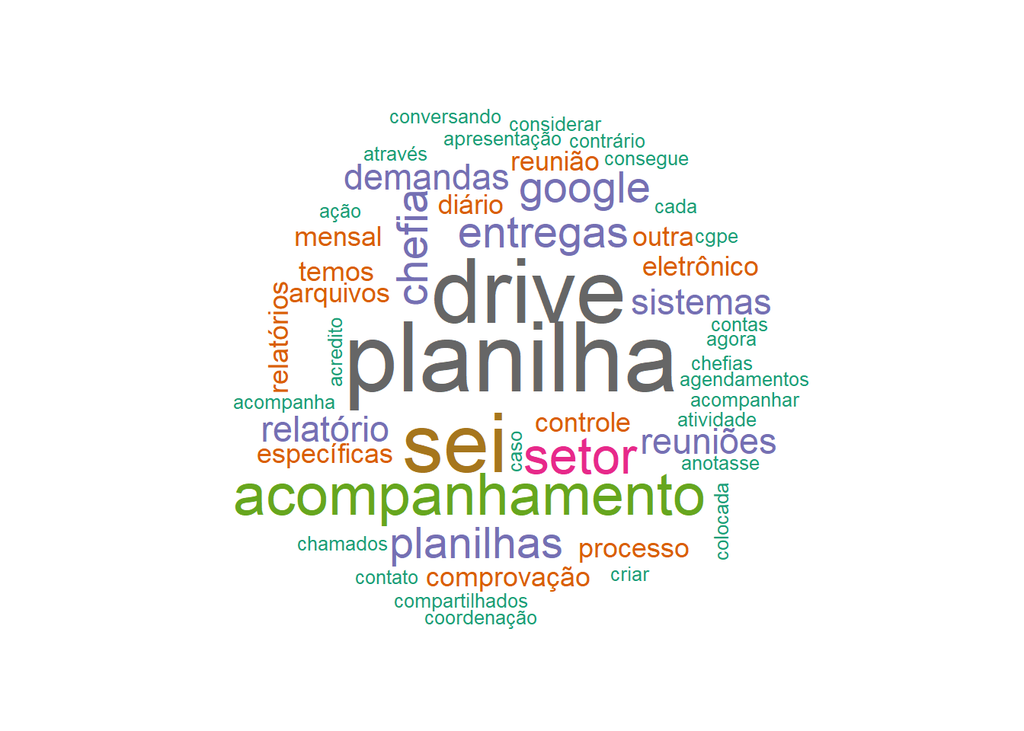

### 6.3.4 Você tem conhecimento das principais novidades do PGD trazidas pela nova portaria?

[interactive chart not shown]

## 6.4 Na sua opinião avalie os fatores que contribuiem

Nessa seção, dividiu-se em bloco para otimizar e facilitar a apresentação e favorecer a analise de questão abaixo:

A seguir, assinale a opção que mais se adequa ao seu nível de concordância com as afirmações abaixo relativas ao teletrabalho, sendo:

“1” discordo totalmente, “2” discordo um pouco, “3” Não discordo nem concordo, “4” Concordo um pouco e “5” concordo totalmente.

### 6.4.1 Bloco - 1

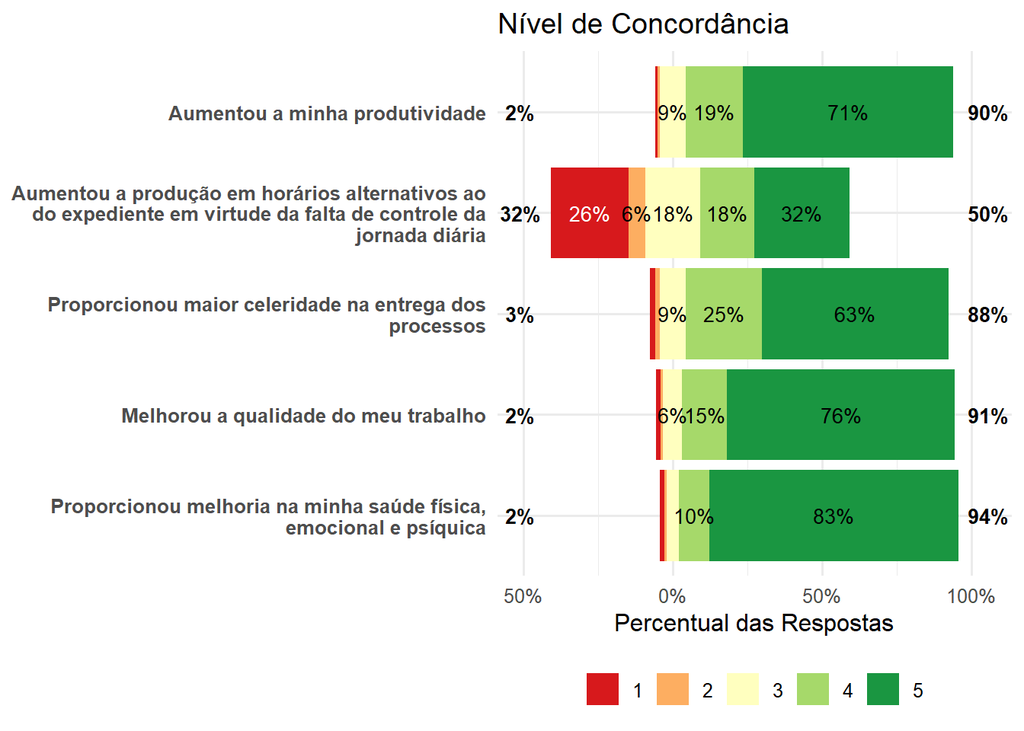

### 6.4.2 Bloco - 2

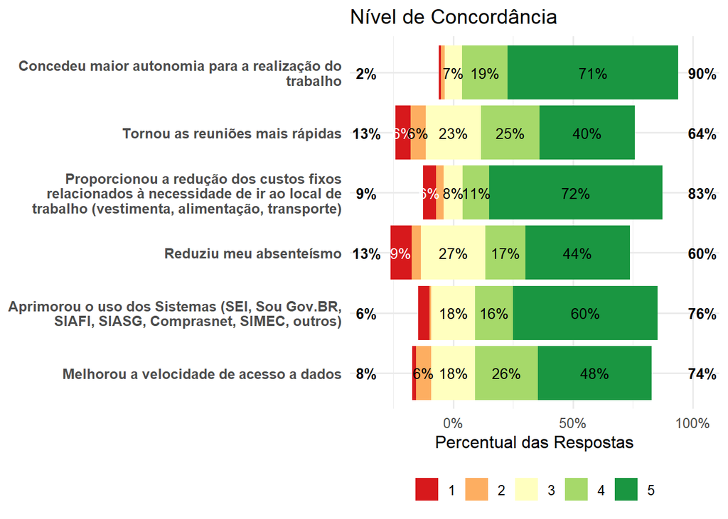

### 6.4.3 Bloco - 3

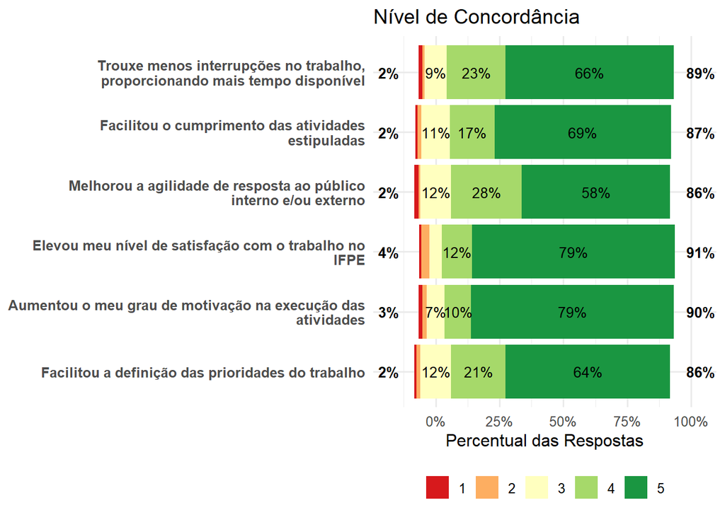

### 6.4.4 Bloco - 4

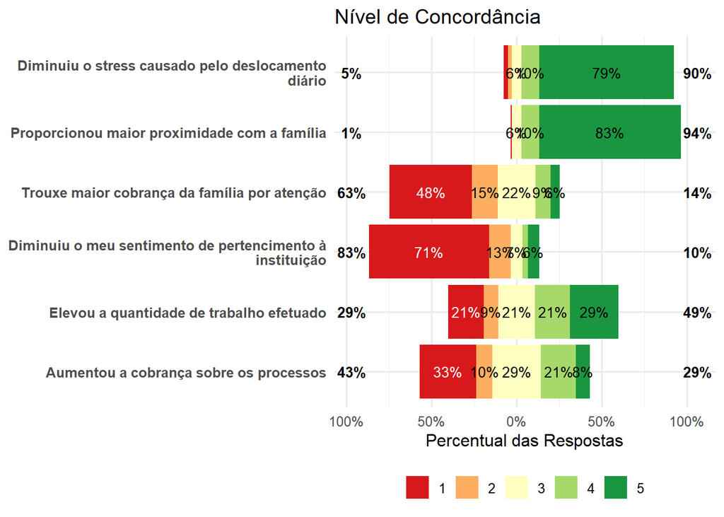

### 6.4.5 Bloco - 5

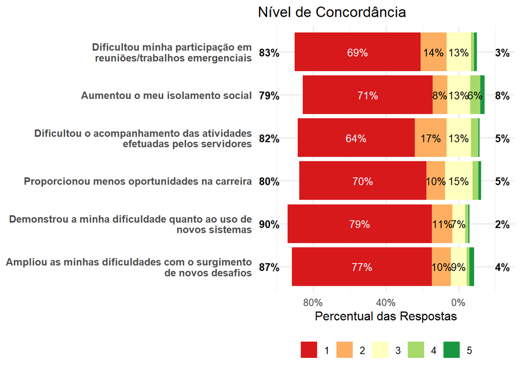

### 6.4.6 Bloco - 6

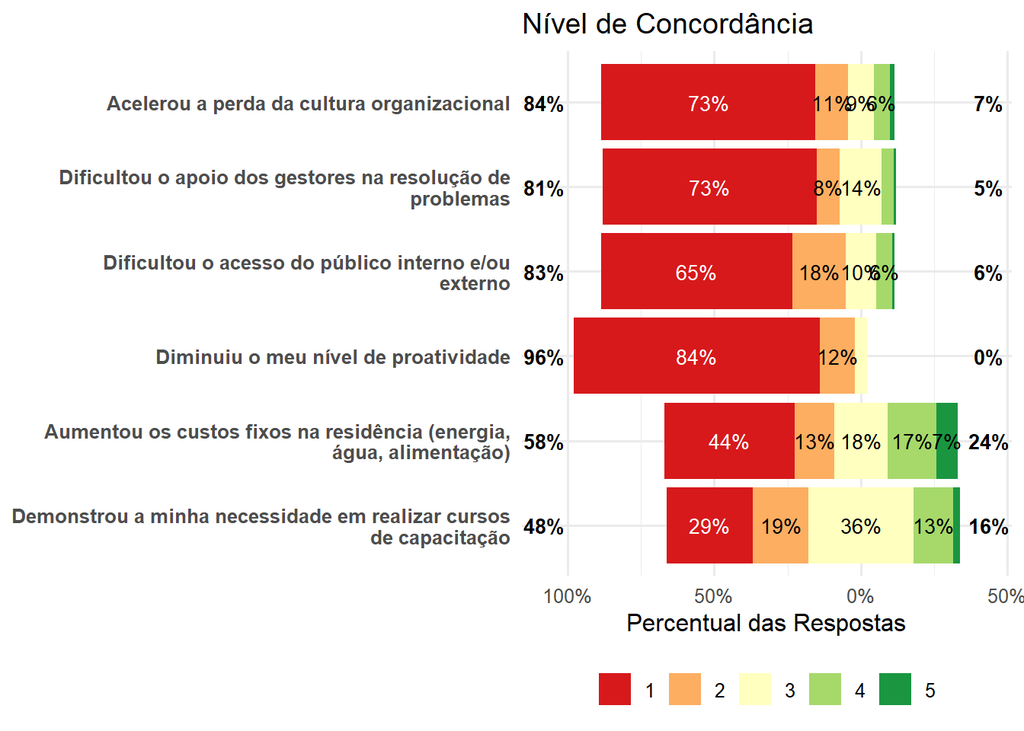

### 6.4.7 Bloco - 7

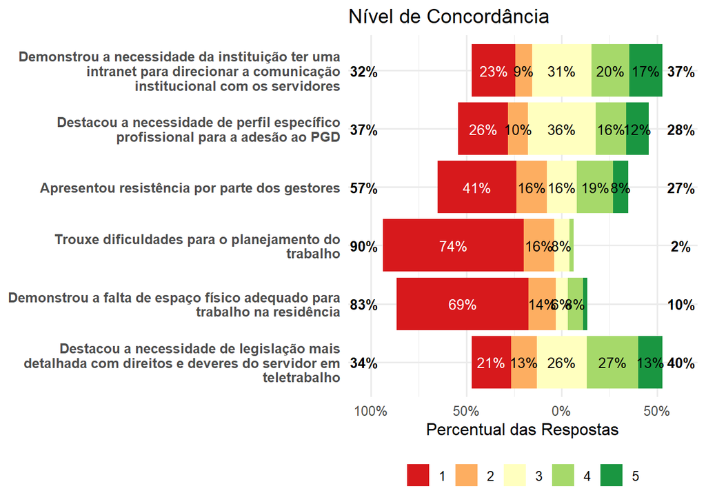

### 6.4.8 Bloco - 8

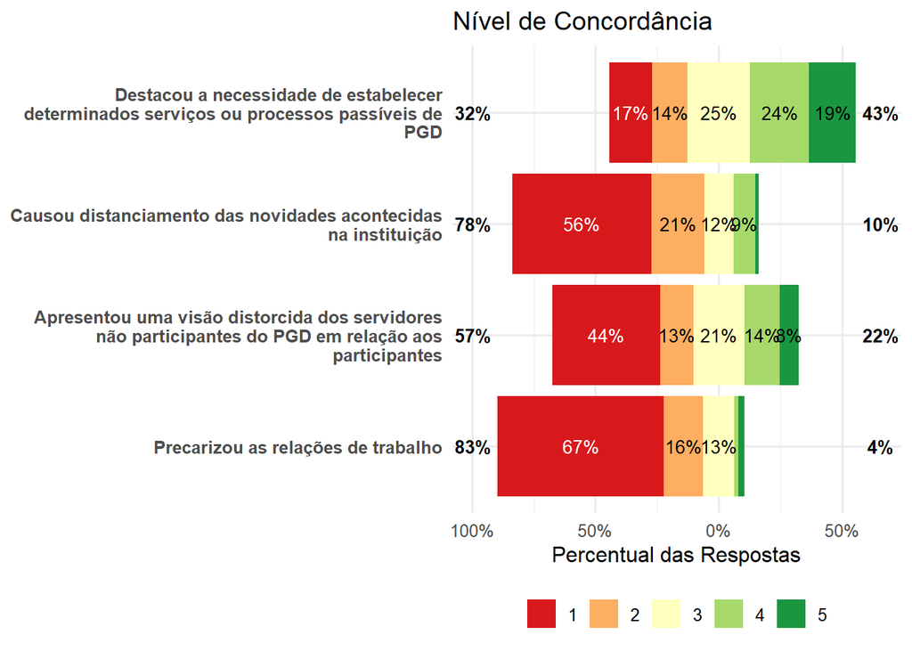

### 6.4.9 Apresento feedback à minha chefia imediata das minhas entregas e dificuldades enfrentadas?

[interactive chart not shown]

## 6.5 Dificuldades

### 6.5.1 Quais dessas dificuldades você sente de forma mais frequente durante a execução do PGD? (Pode marcar mais de uma opção)

[interactive chart not shown]

### 6.5.2 As entregas dos seus planos de trabalho são devidamente avaliadas pela chefia imediata?

[interactive chart not shown]

### 6.5.3 Você recebe feedback das suas entregas pela chefia imediata?

[interactive chart not shown]

### 6.5.4 Considerando a sua relação com outras unidades

Assinale a opção que mais se adequa ao seu nível de concordância com as afirmações abaixo sendo “1” discordo totalmente, “2” discordo um pouco, “3” Não discordo nem concordo, “4” Concordo um pouco e “5” concordo totalmente.

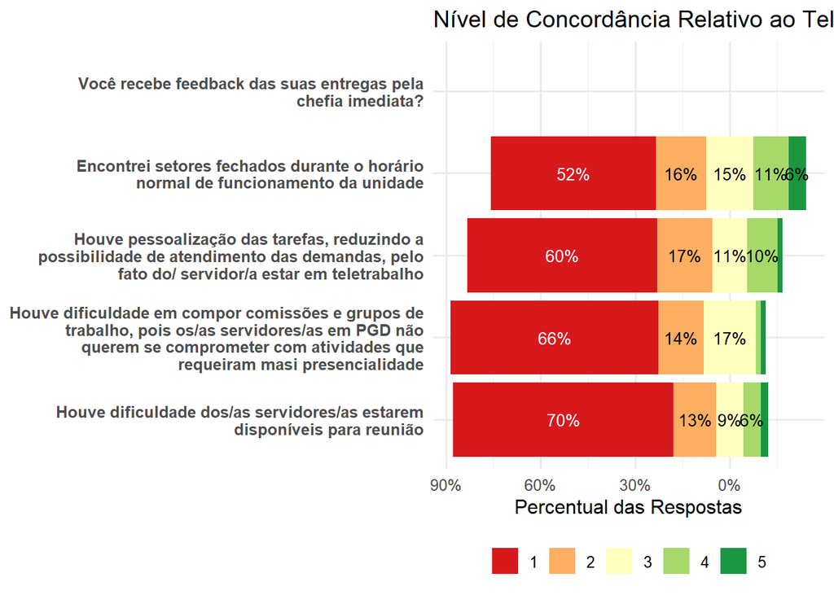

### 6.5.5 Como você avalia a sua participação no PGD?

#### 6.5.5.1 Núvem de palavras das respostas citadas

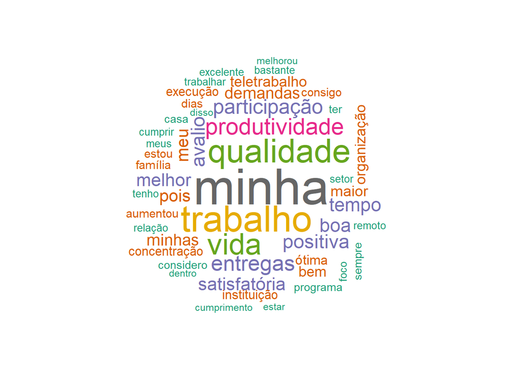

### 6.5.6 Registre aqui seu comentário e/ou sugestão para o aperfeiçoamento do PGD no IFPE:

#### 6.5.6.1 Núvem de palavras das respostas citadas

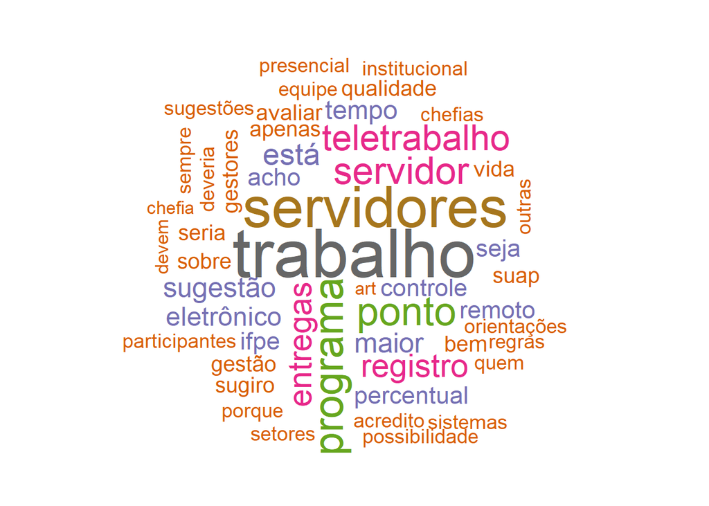

## 6.6 Conclusão e Próximos Passos

Por outro lado o baixo número de entregas alinhadas aos projetos estratégico demonstra que ainda há necessidade de ampliar o conhecimento das estratégias institucionais aos servidores e chefias para que os mesmo possam elaborar seu planos de maneira mais equilibrada ou voltada a estratégia instituicional.